# Part I - PROSPER LOAN DATA EXPLORATION

## by OPARA FEBECHUKWU CHINONYEREM

## Introduction

1. TotalProsperLoans: Number of Prosper loans the borrower had at the time they created this listing. This value will be null if the borrower had no prior loans.
2. OnTimeProsperPayments: Number of on time payments the borrower had made on Prosper loans at the time they created this listing. This value will be null if the borrower has no prior loans.
3. ProsperPaymentsLessThanOneMonthLate: Number of payments the borrower made on Prosper loans that were less than one month late at the time they created this listing. This value will be null if the borrower had no prior loans.
4. ProsperPaymentsOneMonthPlusLate: Number of payments the borrower made on Prosper loans that were greater than one month late at the time they created this listing. This value will be null if the borrower had no prior loans.
5. ProsperPrincipalBorrowed: Total principal borrowed on Prosper loans at the time the listing was created. This value will be null if the borrower had no prior loans.
6. ProsperPrincipalOutstanding:Principal outstanding on Prosper loans at the time the listing was created. This value will be null if the borrower had no prior loans.
7. LoanCurrentDaysDelinquent: The number of days delinquent.
8. LoanFirstDefaultedCycleNumber: The cycle the loan was charged off. If the loan has not charged off the value will be null.
9. LoanMonthsSinceOrigination: Number of months since the loan originated.
10. LoanOriginalAmount: The origination amount of the loan.
11. LoanOriginationDate:The date the loan was originated.
12. MonthlyLoanPayment:The scheduled monthly loan payment.
13. LP_CustomerPayments: Pre charge-off cumulative gross payments made by the borrower on the loan. If the loan has charged off, this value will exclude any recoveries.
14. LP_CustomerPrincipalPayments: Pre charge-off cumulative principal payments made by the borrower on the loan. If the loan has charged off, this value will exclude any recoveries.
15. LP_InterestandFees: Pre charge-off cumulative interest and fees paid by the borrower. If the loan has charged off, this value will exclude any recoveries.
16. LP_GrossPrincipalLoss: The gross charged off amount of the loan.
17. LP_NetPrincipalLoss: The principal that remains uncollected after any recoveries.
18. Investors: The number of investors that funded the loan.
19. LoanStatus: The current status of the loan: Cancelled, Chargedoff, Completed, Current, Defaulted, FinalPaymentInProgress, PastDue. The PastDue status will be accompanied by a delinquency bucket.
20. Recommendations: Number of recommendations the borrower had at the time the listing was created.
21. InvestmentFromFriendsCount: Number of friends that made an investment in the loan.
22. InvestmentFromFriendsAmount: Dollar amount of investments that were made by friends.
23. StatedMonthlyIncome: The monthly income the borrower stated at the time the listing was created.
24. Term: The length of the loan expressed in months.
25. MemberKey: The unique key that is associated with the borrower. This is the same identifier that is used in the API member object.
26. DebtToIncomeRatio:The debt to income ratio of the borrower at the time the credit profile was pulled. This value is Null if the debt to income ratio is not available. This value is capped at 10.01 (any debt to income ratio larger than 1000% will be returned as 1001%).
27. LenderYield: The Lender yield on the loan. Lender yield is equal to the interest rate on the loan less the servicing fee.
28. BorrowerRate:The Borrower's interest rate for this loan.
29. EstimatedEffectiveYield: Effective yield is equal to the borrower interest rate (i) minus the servicing fee rate, (ii) minus estimated uncollected interest on charge-offs, (iii) plus estimated collected late fees. Applicable for loans originated after July 2009.
30. EstimatedLoss: Estimated loss is the estimated principal loss on charge-offs. Applicable for loans originated after July 2009.
31. EstimatedReturn: The estimated return assigned to the listing at the time it was created. Estimated return is the difference between the Estimated Effective Yield and the Estimated Loss Rate. Applicable for loans originated after July 2009.
32. ProsperScore: A custom risk score built using historical Prosper data. The score ranges from 1-10, with 10 being the best, or lowest risk score. Applicable for loans originated after July 2009.

## Preliminary Wrangling

```python
# import all packages and set plots to be embedded inline
import numpy as np
import pandas as pd
import matplotlib.pyplot as plt
import seaborn as sb

%matplotlib inline
```

```python
df_loan = pd.read_csv("prosperLoanData.csv")
df_loan.head()
```

|  | ListingKey | ListingNumber | ListingCreationDate | CreditGrade | Term | LoanStatus | ClosedDate | BorrowerAPR | BorrowerRate | LenderYield | ... | LP_ServiceFees | LP_CollectionFees | LP_GrossPrincipalLoss | LP_NetPrincipalLoss | LP_NonPrincipalRecoverypayments | PercentFunded | Recommendations | InvestmentFromFriendsCount | InvestmentFromFriendsAmount | Investors |
| --- | --- | --- | --- | --- | --- | --- | --- | --- | --- | --- | --- | --- | --- | --- | --- | --- | --- | --- | --- | --- | --- |
| 0 | 1021339766868145413AB3B | 193129 | 2007-08-26 19:09:29.263000000 | C | 36 | Completed | 2009-08-14 00:00:00 | 0.16516 | 0.1580 | 0.1380 | ... | -133.18 | 0.0 | 0.0 | 0.0 | 0.0 | 1.0 | 0 | 0 | 0.0 | 258 |
| 1 | 10273602499503308B223C1 | 1209647 | 2014-02-27 08:28:07.900000000 | NaN | 36 | Current | NaN | 0.12016 | 0.0920 | 0.0820 | ... | 0.00 | 0.0 | 0.0 | 0.0 | 0.0 | 1.0 | 0 | 0 | 0.0 | 1 |
| 2 | 0EE9337825851032864889A | 81716 | 2007-01-05 15:00:47.090000000 | HR | 36 | Completed | 2009-12-17 00:00:00 | 0.28269 | 0.2750 | 0.2400 | ... | -24.20 | 0.0 | 0.0 | 0.0 | 0.0 | 1.0 | 0 | 0 | 0.0 | 41 |
| 3 | 0EF5356002482715299901A | 658116 | 2012-10-22 11:02:35.010000000 | NaN | 36 | Current | NaN | 0.12528 | 0.0974 | 0.0874 | ... | -108.01 | 0.0 | 0.0 | 0.0 | 0.0 | 1.0 | 0 | 0 | 0.0 | 158 |
| 4 | 0F023589499656230C5E3E2 | 909464 | 2013-09-14 18:38:39.097000000 | NaN | 36 | Current | NaN | 0.24614 | 0.2085 | 0.1985 | ... | -60.27 | 0.0 | 0.0 | 0.0 | 0.0 | 1.0 | 0 | 0 | 0.0 | 20 |

5 rows × 81 columns

Let's make some categorical columns to have a datatype of category.

```python
'''Function to make a field a categorical type - nominal or ordinal
    Parameter:
    listOfCategory: This is a list bearing the categories of the field which follows the
    exact order specified for ordinal fields and for nominal fields the order in which
    the values appear in the list is not sticked to.

    field: The dataframe column to make of type category

    order: A boolean value that specifies if the category type is of
    type ordinal or nominal i.e if the order in which the listOfCategory was entered
    should be sticked to or not
'''
def makeCategorical(listOfCategory, field,order):
    #splits the version of the pandas library we are using at the . part
    pd_ver = pd.__version__.split(".")
    #checks if the element at index 0 is > 0 and the element at index 1 >= 21
    if (int(pd_ver[0]) > 0) or (int(pd_ver[1]) >= 21): # i.e we are dealing with pandas version of v0.21 or later
        #Creates the categorical type
        category = pd.api.types.CategoricalDtype(ordered = order, categories = listOfCategory)
        #assigns the categorical type to the field/column
        df_loan[field] = df_loan[field].astype(category)
    else: # for pandas version of v.20
        #make the field of type category without having to create a categorical type first
        df_loan[field] = df_loan[field] .astype('category', ordered = order, categories = listOfCategory)
```

```python
#Making prosper score an ordinal categorical type
prosper_scores = [1,2,3,4,5,6,7,8,9,10]
makeCategorical(prosper_scores, 'ProsperScore',True)
```

```python
#Making loan status a nominal categorical type
loan_status = ['Cancelled',  'Chargedoff', 'Completed', 'Current', 'Defaulted', 'FinalPaymentInProgress', 'PastDue']
makeCategorical(loan_status, 'LoanStatus',False)
```

```python
#Making term a nominal categorical type
term = [12,36,60]
makeCategorical(term, 'Term',False)
```

```python
df_loan['ProsperScore'].dtypes
```

```
CategoricalDtype(categories=[1, 2, 3, 4, 5, 6, 7, 8, 9, 10], ordered=True)
```

```python
df_loan['LoanStatus'].dtypes
```

```
CategoricalDtype(categories=['Cancelled', 'Chargedoff', 'Completed', 'Current',
                  'Defaulted', 'FinalPaymentInProgress', 'PastDue'],
                 ordered=False)
```

```python
df_loan['Term'].dtypes
```

```
CategoricalDtype(categories=[12, 36, 60], ordered=False)
```

```python
df_loan.shape
```

```
(113937, 81)
```

```python
print(df_loan.dtypes)
```

[output not shown]

### Structure of the Dataset

> The dataset contains 113937 rows and 81 columns.

### Main Features of Interest in the Dataset

> The main features of interest include:
> 1. LoanStatus
> 2. BorrowerAPR
> 3. BorrowerRate
> 4. LenderYield
> 5. EstimatedEffectiveYield
> 6. EstimatedLoss
> 7. EstimatedReturn
> 8. ProsperScore
> 9. Term

### Investigation Supporting Features

> The features that will support my investigation of the above listed features include:
> 1. TotalProsperLoans
> 2. OnTimeProsperPayments
> 3. ProsperPaymentsLessThanOneMonthLate
> 4. ProsperPaymentsOneMonthPlusLate
> 5. ProsperPrincipalBorrowed
> 6. StatedMonthlyIncome
> 7. LP_CustomerPrincipalPayments
> 8. LP_InterestandFees
> 9. DebtToIncomeRatio
> 10. ProsperPrincipalOutstanding
> 11. ProsperPrincipalBorrowed
> 12. LP_NetPrincipalLoss
> 13. LP_GrossPrincipalLoss
> 14. MonthlyLoanPayment
> 15. StatedMonthlyIncome
> 16. InvestmentFromFriendsAmount
> 17. LoanOriginalAmount

## Univariate Exploration

**Investigation of Loan Status Distribution**

> It is a categorical data, so we would use a bar chart to investigate it's distribution.

```python
df_loan['LoanStatus'].unique()
```

[output not shown]

```python
'''Creates a barChart
    dat: The dataframe to pull the data from
    column: The column to create the barchart for
    colo: The color for the bars
'''
def barChart(dat, column, colo):
    #Creates the barchart with order being the order the index values of series returned by value_counts
    sb.countplot(data=dat, x=column,color=colo,order=dat[column].value_counts().index);
    #rotates the tick values of x axis to be at 90 degree
    plt.xticks(rotation=90)
```

```python
base_color = sb.color_palette()[0]
```

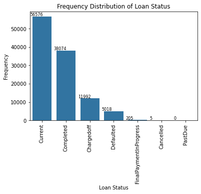

```python
barChart(df_loan, "LoanStatus", base_color)
plt.title("Frequency Distribution of Loan Status")
plt.xlabel("Loan Status")
plt.ylabel("Frequency")

series = df_loan['LoanStatus'].value_counts()

# Logic to print the frequency text on the bars
j=0
for i in series.index:
    count = series[j]
    # Convert count into a string
    pct_string = '{:d}'.format(series[j])
    # Print the string value on the bar.
    plt.text(j-0.5, count+1000, pct_string, fontsize=8, va='center')
    #increment j so as to pick the next count value
    j = j+1
plt.figure(figsize=(20,10))
```

```python
df_loan['LoanStatus'].value_counts()
```

```
Current                   56576
Completed                 38074
Chargedoff                11992
Defaulted                  5018
FinalPaymentInProgress      205
Cancelled                     5
PastDue                       0
Name: LoanStatus, dtype: int64
```

**Investigation of Loan Original Amount Frequency Distribution**

LoanOriginalAmount is a numeric data, so we would use a histogram to univariately view it distribution.

```python
''' Plots a histogram
    dat: The dataframe to pull the data from
    xcolumn: The column of the dataframe to plot the frequency distribution
    bins: The bin sizing to be used in plotting the histogram
    xlab: The label of the x axis
    ylab: The label of the y axis
    title: The title of the plot
'''
def histogram(dat, xcolumn, colo, bins, xlab,ylab,title):
    #plots the histogram using the bin sizes issued
    plt.hist(data=dat, x=xcolumn, bins=bins);
    plt.xlabel(xlab)
    plt.ylabel(ylab)
    plt.title(title)
```

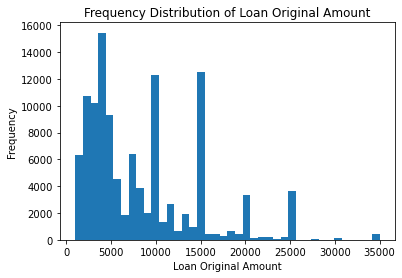

```python
histogram(df_loan,"LoanOriginalAmount",base_color, 40,"Loan Original Amount","Frequency","Frequency Distribution of Loan Original Amount")
```

```python
df_loan['LoanOriginalAmount'].value_counts()
```

```
4000     14333
15000    12407
10000    11106
5000      6990
2000      6067
         ...
14383        1
6251         1
14447        1
6379         1
4098         1
Name: LoanOriginalAmount, Length: 2468, dtype: int64
```

Loans of 4000, 15000,10000 tends to be most in frequency and loans of 2000, 5000 follows and then loans of 20000 and 25000.

**Investigation of InvestmentFromFriendsAmount Frequency Distribution**

The data is a numeric data, so we would use a histogram to visualize it univariately.

```python
df_loan['InvestmentFromFriendsAmount'].value_counts()
```

```
0.00       111806
50.00         323
100.00        242
1000.00       100
500.00         97
            ...
48.51           1
102.34          1
53.27           1
953.33          1
501.99          1
Name: InvestmentFromFriendsAmount, Length: 726, dtype: int64
```

```python
df_loan['InvestmentFromFriendsAmount'].describe()
```

```
count    113937.000000
mean         16.550751
std         294.545422
min           0.000000
25%           0.000000
50%           0.000000
75%           0.000000
max       25000.000000
Name: InvestmentFromFriendsAmount, dtype: float64
```

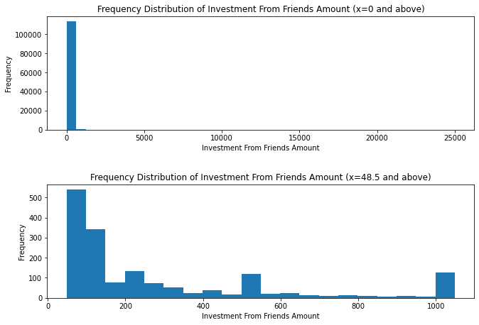

```python
#subplot of both plots
plt.figure(figsize=[10,7])
plt.subplot(2,1,1)
histogram(df_loan, 'InvestmentFromFriendsAmount', base_color, 40, "Investment From Friends Amount","Frequency","Frequency Distribution of Investment From Friends Amount (x=0 and above)")
plt.subplot(2,1,2)
bins=np.arange(48.5,1000+50,50)
histogram(df_loan, 'InvestmentFromFriendsAmount', base_color, bins, "Investment From Friends Amount","Frequency","Frequency Distribution of Investment From Friends Amount (x=48.5 and above)")
#Pads the subplot i.e to space them out
plt.tight_layout(pad=3.0)
```

The frequency of zero seems to be very high from others, so in the second subplot we would remove zero and only plot values from 48.51 to 1000 in order to see the distribution of the values greater than zero clearly.

In the absence of zero as the mode, the distribution seems multi-modal.

Majority of friends are not investing in the Prosper customer's loan as zero is modal value.

**Investigation of Investors Distribution**

```python
df_loan['Investors'].value_counts()
```

```
1      27814
2       1386
3        991
4        827
5        753
       ...
881        1
801        1
752        1
715        1
831        1
Name: Investors, Length: 751, dtype: int64
```

It is a numeric data column, so we would use a histogram still to visualize it univariantly.

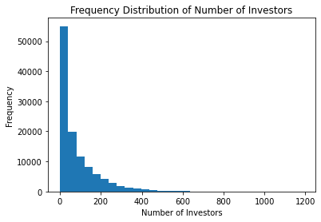

```python
histogram(df_loan, 'Investors', base_color, 30, "Number of Investors","Frequency","Frequency Distribution of Number of Investors")
```

The distribution is having a long tail at the right, so let's view the Kernel Density Estimate plot of the distribution.

```python
def seaborn_histogram(series, bins_edges,kde, hist_kws,xlab,ylab,titl):
    sb.distplot(series,bins=bins_edges, kde=kde,hist_kws = hist_kws);
    plt.xlabel(xlab)
    plt.ylabel(ylab)
    plt.title(titl)
```

[output not shown]

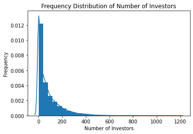

```python
seaborn_histogram(df_loan['Investors'],30, True,{'alpha':1},"Number of Investors","Frequency","Frequency Distribution of Number of Investors")
```

From Seaborn's Kernel Density Estimate plot, we can observe that Investors distribution is right skewed.

**Investigation of StatedMonthlyIncome Distribution**

```python
df_loan['StatedMonthlyIncome'].describe()
```

```
count    1.139370e+05
mean     5.608026e+03
std      7.478497e+03
min      0.000000e+00
25%      3.200333e+03
50%      4.666667e+03
75%      6.825000e+03
max      1.750003e+06
Name: StatedMonthlyIncome, dtype: float64
```

The field is a numeric field so we will go with a histogram as the visualization plot.

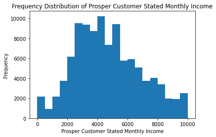

```python
bins=np.arange(0.0,10000+500,500)
histogram(df_loan, 'StatedMonthlyIncome', base_color, bins, "Prosper Customer Stated Monthly Income","Frequency","Frequency Distribution of Prosper Customer Stated Monthly Income")
```

**Investigation of MonthlyLoanPayment Frequency Distribution**

It is a numeric field, so we will go with a histogram to visualize it.

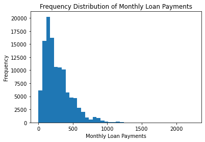

```python
histogram(df_loan, 'MonthlyLoanPayment', base_color, 40, "Monthly Loan Payments","Frequency","Frequency Distribution of Monthly Loan Payments")
```

From observation, MonthlyLoanPayment distribution is right skewed.

**Investigation of LP_GrossPrincipalLoss Frequency Distribution**

It is also a numeric variable, so we would go with a histogram.

```python
df_loan['LP_GrossPrincipalLoss'].value_counts()
```

```
0.00       97034
4000.00       84
3000.00       50
1000.00       49
2000.00       45
           ...
1296.57        1
637.85         1
3576.60        1
2278.82        1
1849.07        1
Name: LP_GrossPrincipalLoss, Length: 15848, dtype: int64
```

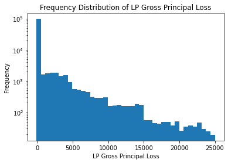

```python
histogram(df_loan, 'LP_GrossPrincipalLoss', base_color, 40, "LP Gross Principal Loss","Frequency","Frequency Distribution of LP Gross Principal Loss")
plt.yscale("log")
```

It seems like Prosper don't incur losses in principal of loans they issue out, as can be seen that small principal amounts are much than larger principal amounts.

**Investigation of the Frequency Distribution of LP_NetPrincipalLoss**

It is a numeric field. so we would also go with the histogram.

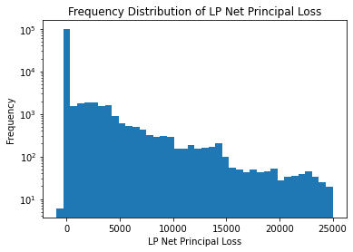

```python
histogram(df_loan, 'LP_NetPrincipalLoss', base_color, 40, "LP Net Principal Loss","Frequency","Frequency Distribution of LP Net Principal Loss")
plt.yscale("log")
```

LP_NetPrincipalLoss and LP_GrossPrincipalLoss are almost having the same distribution. On the net, Prosper do not incur high principal losses.

**Investigation of Frequency Distribution of ProsperPrincipalBorrowed**

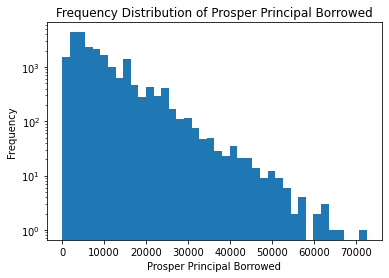

```python
histogram(df_loan, 'ProsperPrincipalBorrowed', base_color, 40, "Prosper Principal Borrowed","Frequency","Frequency Distribution of Prosper Principal Borrowed")
plt.yscale("log")
```

**Investigation of Frequency Distribution of ProsperPrincipalOutstanding**

It is also a numeric value so we would go with a histogram.

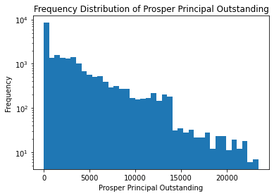

```python
histogram(df_loan, 'ProsperPrincipalOutstanding', base_color, 40, "Prosper Principal Outstanding","Frequency","Frequency Distribution of Prosper Principal Outstanding")
plt.yscale("log")
```

Majority of Prosper borrowers don't have a running borrowed principal as at the time they borrow new loans, but we cannot conclude that explicitly as the sum of all customers above with outstanding principal borrowed definitely will surpass the frequency of the modal value, which is zero(0).

**Investigation of BorrowerAPR Frequency Distribution**

It is a numeric data we will go with a histogram.

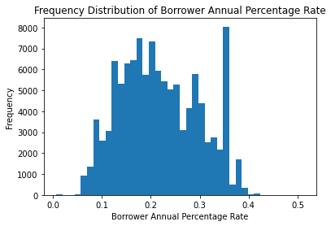

```python
histogram(df_loan, 'BorrowerAPR', base_color, 40,"Borrower Annual Percentage Rate","Frequency","Frequency Distribution of Borrower Annual Percentage Rate")
```

```python
df_loan['BorrowerAPR'].value_counts()
```

```
0.35797    3672
0.35643    1644
0.37453    1260
0.30532     902
0.29510     747
           ...
0.22825       1
0.22955       1
0.24844       1
0.30775       1
0.11833       1
Name: BorrowerAPR, Length: 6677, dtype: int64
```

0.35797 is the modal value, It has a frequency of 3,672.

**Investigation of BorrowerRate Frequency Distribution**

It is a numeric set, so a histogram will do.

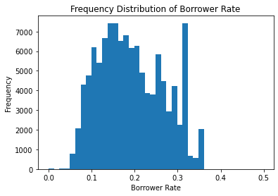

```python
histogram(df_loan, 'BorrowerRate', base_color, 40,"Borrower Rate","Frequency","Frequency Distribution of Borrower Rate")
```

```python
df_loan['BorrowerRate'].describe()
```

```
count    113937.000000
mean          0.192764
std           0.074818
min           0.000000
25%           0.134000
50%           0.184000
75%           0.250000
max           0.497500
Name: BorrowerRate, dtype: float64
```

```python
df_loan['BorrowerRate'].mode()
```

```
0    0.3177
dtype: float64
```

```python
df_loan['BorrowerRate'].value_counts()
```

```
0.3177    3672
0.3500    1905
0.3199    1651
0.2900    1508
0.2699    1319
          ...
0.2717       1
0.1732       1
0.1704       1
0.1786       1
0.1721       1
Name: BorrowerRate, Length: 2294, dtype: int64
```

The modal value is 0.3177. It has a frequency of 3672.

**Investigation of LenderYield Frequency Distribution**

It is a numeric value, so histogram is best to view it univariately.

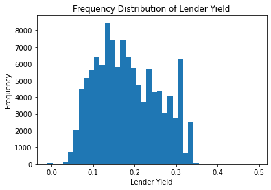

```python
histogram(df_loan, 'LenderYield', base_color, 40,"Lender Yield","Frequency","Frequency Distribution of Lender Yield")
```

```python
df_loan['LenderYield'].value_counts()
```

```
0.3077    3672
0.3400    1916
0.3099    1651
0.2599    1318
0.1450    1011
          ...
0.1756       1
0.3288       1
0.2331       1
0.1953       1
0.3333       1
Name: LenderYield, Length: 2283, dtype: int64
```

The modal value is 0.3077, it has a frequency of 3672.

**Investigation of EstimatedEffectiveYield Frequency Distribution**

It is also a numeric set, so we would use a histogram

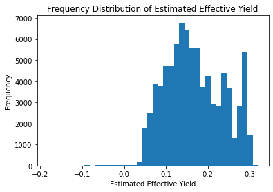

```python
histogram(df_loan, 'EstimatedEffectiveYield', base_color, 40,"Estimated Effective Yield","Frequency","Frequency Distribution of Estimated Effective Yield")
```

```python
df_loan['EstimatedEffectiveYield'].value_counts()
```

```
 0.2896    3064
 0.2957    1041
 0.2534     966
 0.2437     747
 0.2000     643
           ...
 0.0134       1
-0.0813       1
 0.0380       1
-0.0332       1
 0.1578       1
Name: EstimatedEffectiveYield, Length: 1582, dtype: int64
```

Estimated Effective Yield has negative values but their frequency isn't much. The modal value is 0.2896, which has a frequency of 3064.

**Investigation of EstimatedLoss Frequency Distribution**

It is also a numeric set, so a histogram can visualize it's frequency distribution.

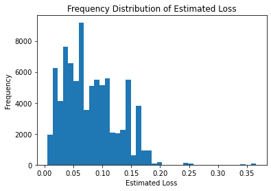

```python
histogram(df_loan, 'EstimatedLoss', base_color, 40,"Estimated Loss","Frequency","Frequency Distribution of Estimated Loss")
```

```python
df_loan['EstimatedLoss'].value_counts()
```

```
0.1650    2586
0.1470    2365
0.0595    1837
0.1120    1786
0.0599    1742
          ...
0.0470      13
0.0950      12
0.0049      11
0.0840       9
0.1140       1
Name: EstimatedLoss, Length: 120, dtype: int64
```

The modal value is 0.1650, it has a frequency of 2586.

**Investigation of the Frequency Distribution of EstimatedReturn**

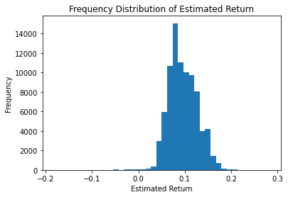

```python
histogram(df_loan, 'EstimatedReturn', base_color, 40,"Estimated Return","Frequency","Frequency Distribution of Estimated Return")
```

```python
df_loan['EstimatedReturn'].value_counts()
```

```
0.1246    2217
0.1487    1097
0.0691     760
0.1414     738
0.1074     654
          ...
0.2264       1
0.2021       1
0.0219       1
0.1771       1
0.1900       1
Name: EstimatedReturn, Length: 1476, dtype: int64
```

Estimated Return has some negative values and the mode is distinct. The modal value is 0.1246, it has a frequency of 2217.

**Investigation of the Frequency Distribution of ProsperScore**

It is an ordinal value so we would use bar chart to visualize it.

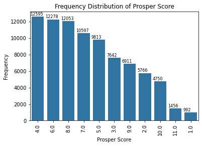

```python
barChart(df_loan, "ProsperScore", base_color)
plt.title("Frequency Distribution of Prosper Score")
plt.xlabel("Prosper Score")
plt.ylabel("Frequency")

series = df_loan['ProsperScore'].value_counts()

# Logic to print the frequency text on the bars
j=0
for i in series.index:
    count = series[i]
    # Convert count into a percentage, and then into string
    pct_string = '{:d}'.format(series[i])
    # Print the string value on the bar.
    plt.text(j-0.5, count+300, pct_string, fontsize=8, va='center')
    j = j+1
plt.figure(figsize=(20,10))
```

The modal score is 4.0, the best score being 10, that implies low risk, being just 4750 indicates that most Prosper loans are not risky. Their Portfolio has loans with mild risk. And from observation we have a score of 11, whereas the Prosper score ranges from 1-10, so we would clean that and set them to the modal value which is 4.0.

```python
'''Sets the ProsperScore of value 11 to the modal Value
    x: The ProsperScore to be tested if it's 11
    returns the value if it isn't 11 or returns the mode which is 4 if it is 11
'''
def setToMode(x):
    if x == 11:
        return 4
    else:
        return x

df_loan['ProsperScore'] = df_loan['ProsperScore'].apply(lambda x: setToMode(x))
```

Now let's replot out bar chart.

```python
df_loan['ProsperScore'].value_counts()
```

```
4     14051
6     12278
8     12053
7     10597
5      9813
3      7642
9      6911
2      5766
10     4750
1       992
Name: ProsperScore, dtype: int64
```

```python
df_loan['ProsperScore'].value_counts()[0]
```

```
14051
```

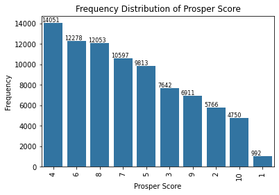

```python
barChart(df_loan, "ProsperScore", base_color)
plt.title("Frequency Distribution of Prosper Score")
plt.xlabel("Prosper Score")
plt.ylabel("Frequency")

series = df_loan['ProsperScore'].value_counts()

# Logic to print the frequency text on the bars
j=0
for i in series.index:
    count = series[j]
    # Convert count into a percentage, and then into string
    pct_string = '{:d}'.format(series[j])
    # Print the string value on the bar.
    plt.text(j-0.5, count+300, pct_string, fontsize=8, va='center')
    j = j+1
plt.figure(figsize=(20,10))
```

The modal frequency becomes 14051. The best score being 10, and we have majority as 4, we need to know why Prosper has majority of his loan having a score of 4.

**Investigation of Frequency Distribution of Loan Term**

We would use a bar chart since we are dealing with a qualitative variable.

[figure not shown]

```python
barChart(df_loan, "Term", base_color)
plt.title("Frequency Distribution of Prosper Score")
plt.xlabel("Term")
plt.ylabel("Frequency")
```

Loans of term 12 is the least and loans of term 36 is the most.

### Unusual Point and Transformation Performed on the Dataset

> One unusual point I discovered was a Prosper Score of 11, whereas the set is from 1-10, I simply made all ProsperScores equal to 11 to become the modal value 4. In order to view the distribution of certain data sets, I had to issue a customized bin to the histogram function I wrote and for some I had to do a log transform on the y axis.

### Operation performed to Tidy Data set

> The data had ordinal values of Prosper score showing as float type I had to clean it and make it of type Category, also the nominal type of Loan Status that was showing as object type was also made an unordered category type. A prosper score of 11 was turned to the modal value of 4, since we have prosper score of 1-10 and 11 is not among the set.

## Bivariate Exploration

Before we move on with our Bivariate exploration, we need to see a grid of relationships to see which of our fields of interest are related to each other using a plot matrix.

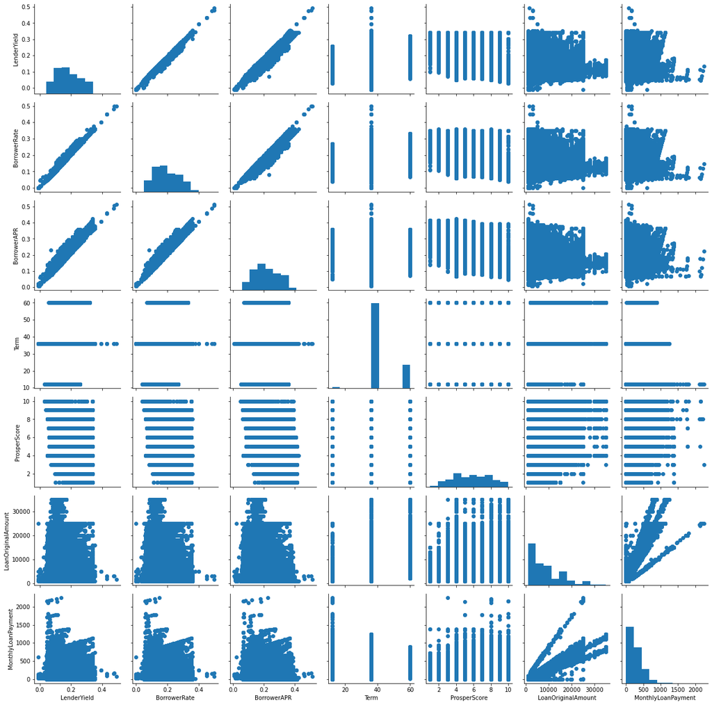

```python
#Plot a Plot Matrix
columns_to_study = ['LenderYield','BorrowerRate','BorrowerAPR','Term','ProsperScore','LoanOriginalAmount','MonthlyLoanPayment']
#Create the plot matrix object
g=sb.PairGrid(data=df_loan, vars=columns_to_study );
#Plot a scatter plot
g=g.map_offdiag(plt.scatter);
#Plot a histogram instead on the diagonals
g.map_diag(plt.hist)
```

Let view the correlations clearly by using a correlation heat map.

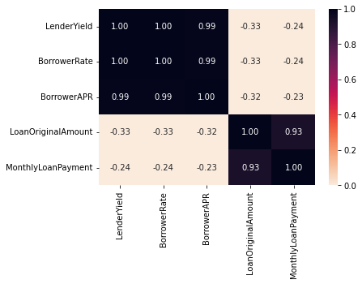

```python
columns_to_study = ['LenderYield','BorrowerRate','BorrowerAPR','Term','ProsperScore','LoanOriginalAmount','MonthlyLoanPayment']
correlation = df_loan[columns_to_study].corr()
sb.heatmap(correlation, cmap='rocket_r', annot=True, fmt='.2f', vmin=0);
```

**Relationships Observed from the Plot Matrix 1**

1. LenderYield is related to BorrowerRate and BorrowerAPR.There are also seems to be a relationship between LenderYield and LoanOriginalAmount and MonthlyLoanPayment but we need to apply jittering or sampling or transparency to be able to view the relationship as we have overplotting. LenderYield seems like it would have a relationship with Term and ProsperScore but we need to pick a more appropriate Bivariate visualization tool in order to ascertain that.
2. BorrowerRate is related to BorrowerAPR. It also seems that BorrowerRate is related to LoanOriginalAmount and MonthlyLoanPayment but overplotting is obscuring it. We would pick a better plot to test if BorrowerRate is related to Term and ProsperScore.
3. BorrowerAPR also seems to be related to LoanOriginalAmount and MonthlyLoanPayment but the relationship is obscured by overplotting. We would ascertain if it is related to Term and ProsperScore by picking an appropriate plotting tool like the Violin plot.
4. Term and ProsperScore seems it is plotted with the appropriate plotting tool but there seems to be a relationship between it and other variables, we would ascertain this using a Violin plot.

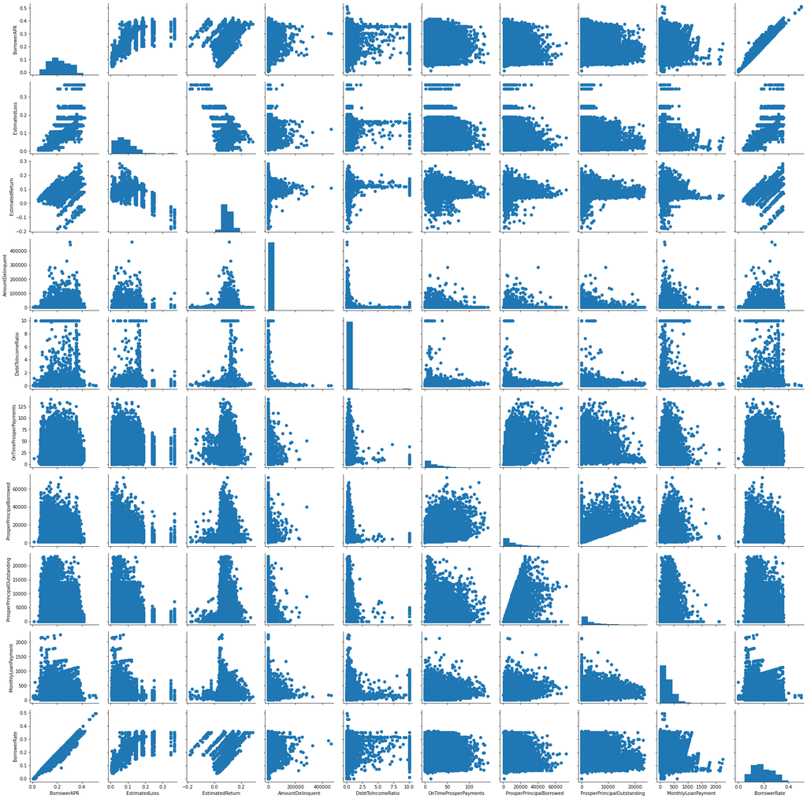

```python
columns_to_study = ['BorrowerAPR','EstimatedLoss','EstimatedReturn','AmountDelinquent','DebtToIncomeRatio','OnTimeProsperPayments','ProsperPrincipalBorrowed','ProsperPrincipalOutstanding','MonthlyLoanPayment','BorrowerRate']
g=sb.PairGrid(data=df_loan, vars=columns_to_study );
g=g.map_offdiag(plt.scatter);
g.map_diag(plt.hist)
```

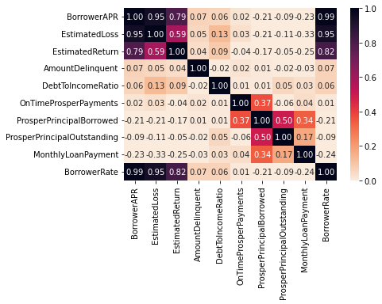

```python
columns_to_study = ['BorrowerAPR','EstimatedLoss','EstimatedReturn','AmountDelinquent','DebtToIncomeRatio','OnTimeProsperPayments','ProsperPrincipalBorrowed','ProsperPrincipalOutstanding','MonthlyLoanPayment','BorrowerRate']
correlation = df_loan[columns_to_study].corr()
sb.heatmap(correlation, cmap='rocket_r', annot=True, fmt='.2f', vmin=0);
```

**Relationships Observed from the Plot Matrix 2**

**Is LenderYield affected by BorrowerAPR?**

**Bivariate Plot of LenderYield to BorrowerAPR**

They are both numeric fields so we would use a scatter plot.

```python
'''Function to create a Bivariate scatter plot
df: dataframe to pull the data from
col_x: the x axis column
col_y: the y axis column
alpha: the transparency to apply to the scatter plot
xlab: x axis description
ylab: y axis description
title: the title of the plot
'''
def scatterPlot(df, col_x, col_y, alpha, xlab, ylab, title):
    plt.scatter(data=df, x=col_x,y=col_y,alpha=alpha);
    plt.xlabel(xlab)
    plt.ylabel(ylab)
    plt.title(title)
```

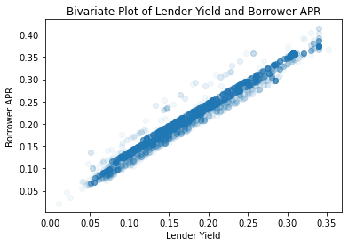

```python
scatterPlot(df_loan.sample(5000), 'LenderYield', 'BorrowerAPR', 1/20,'Lender Yield','Borrower APR', 'Bivariate Plot of Lender Yield and Borrower APR')
```

There appears to be a linear relationship between LenderYield and BorrowerAPR, that is to say loans with High BorrowerAPR yields more and loans with Low BorrowerAPR yields less.

**Since BorrowerAPR and BorrowerRate are strongly correlated, will there be same correlation between BorrowerRate and LenderYield?**

**Bivariate Plot of LenderYield to BorrowerRate**

They are both numeric fields so we would use a scatter plot.

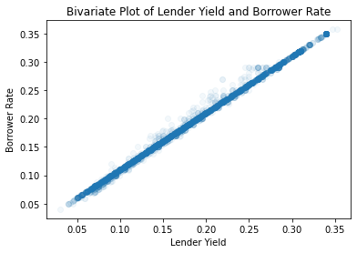

```python
scatterPlot(df_loan.sample(5000), 'LenderYield', 'BorrowerRate', 1/20,'Lender Yield','Borrower Rate', 'Bivariate Plot of Lender Yield and Borrower Rate')
```

BorrowerRate is also linearly related to LenderYield.

**BorrowerRate maybe determined by the term of the loan to control the risk associated with such loan, so the next question is, is LenderYield connected to BorrowerRate affected by Term?**

**Bivariate Plot of LenderYield to Term**

This is a quantitative set and a qualitative set, so we would use a violin plot.

```python
''' Function to create a violin plot
df: dataframe to pull the data from
xcol: the column for the x axis
ycol: the column for the y axis
colo: the color for the violins
inne: whether to include the inner box plot
xlab: the x axis description
ylab: the y axis description
title: the title of the plot
'''
def violin(df, xcol, ycol, colo, inne, xlab, ylab, title):
    sb.violinplot(data=df, x=xcol, y=ycol, color=colo, inner=inne);
    plt.xticks(rotation=90)
    plt.xlabel(xlab)
    plt.ylabel(ylab)
    plt.title(title)
```

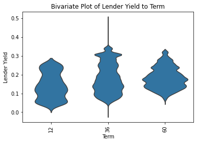

```python
violin(df_loan,'Term','LenderYield',base_color,None, 'Term','Lender Yield','Bivariate Plot of Lender Yield to Term')
```

Loans with Term of 36 seems to be more at LenderYield of 0.3, Loans with terms of 60 seems to more at around 0.1 and 0.2 yield. The highest yield is given by loans of Term 36. Loans of Term 12, 60 and 36 seems to have a multi-modal lender yield. LenderYield is affected by Term, as we can see loans of lower term gave lower yield and loans of higher term gave higher yield, but this isn't explicit, Prosper needs to issue more loans of Term 36 and 60 at a higher borrower rate than loans of Term 12 to shoulder the risk associated with such loans. This raises the need to view the multivariate plot of LenderYield, Term and ProsperScore, to see if Prosper is classifying the risk level of her loans appropriately.

**LenderYield is related to Term, in the sense that higher Term loans give a higher yield, expected high yield may also mean a big loss should the customer default,the next question is, Is Prosper classifying the risk level of her loans according to Term and LenderYield?**

**Bivariate Plot of LenderYield to ProsperScore**

This will also go with a Violin plot since it is a qualitative and quantitative variable.

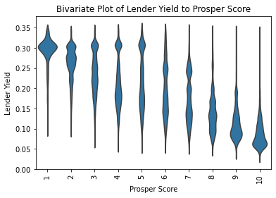

```python
violin(df_loan,'ProsperScore','LenderYield',base_color,None, 'Prosper Score','Lender Yield','Bivariate Plot of Lender Yield to Prosper Score')
```

From the above plot, Prosper loans with high risk factor (prosper score of 1) yields more than loans with low risk factor (prosper score of 10). Prosper is actually assigning the ProsperScore appropriately, but there is need to view a plot ProsperScore and Term to see that Loans of Term 12 were classifed as less risky than loans of Term 10.

**Is Prosper classifying Long Term loans as more risky than short term Loans**

**Bivariate Relationship between Term and ProsperScore**

They are both qualitative variables so we would use a clustered bar chart to visualize their relationship.

```python
'''A function to create a clustered bar chart
 df: the dataframe to pull the data from
 x_col: the column that should be on x axis
 hue_col: the column that the hue should be applied to
 xlab: x axis description
 ylab: y axis description
 titl: the title of chart
'''
def clusteredBarChart(df, x_col, hue_col, xlab,ylab,titl):
    sb.countplot(data=df,x=x_col,hue=hue_col);
    plt.xlabel(xlab)
    plt.ylabel(ylab)
    plt.title(titl)
```

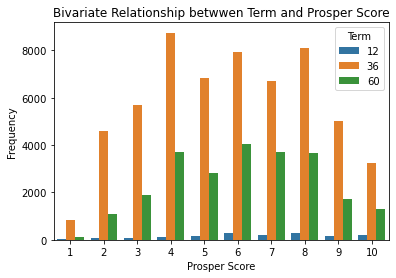

```python
clusteredBarChart(df_loan,  'ProsperScore', 'Term', "Prosper Score","Frequency","Bivariate Relationship betwwen Term and Prosper Score")
```

The relationship shows that Prosper is not classifying loans of term 60 and 36 as more risky than loans of term 12, this has to be taken care off, because the less time I have to recover my principal and associated yield, the less risky the lending is for me. Loan of term 60 should be more in ProsperScore of 1-5, loan of term 36 kept at the average and loan of term 12 should be more in ProsperScore of 6-10.

**The next question is LenderYield affected by the Loan's Original Amount?**

**Bivariate Plot of LenderYield to LoanOriginalAmount**